# Non-demeaned clustering

Antal Ertl

2023 03 01

### Defining the number of Principal Components to look at

Using the demeaned data, the factor choice is no longer clear at factor = 4 but it is good enough

Alternatively, look at the number of Principal Components to attaint using Parallel Analysis.

Parallel Analysis: specify how many components to retain using simulation

Here, we get the critical values for each component. If the eigenvalues from the PCA are greater than the value at 0.95 confint, we can retain given component.

We have two rules: 1) Kaiser’s rule: Eigenvalue has to be >1 (satisfied up to 4 factors, with the 4th being barely above) 2) Eigenvalues being greater than the estimates gathered from Parallel Analysis (Horn, 1965)

```
##
##  Parallel Analysis Results
##
## Method: pca
## Number of variables: 4
## Sample size: 1108
## Number of correlation matrices: 500
## Seed: 1234
## Percentile: 0.95
##
## Compare your observed eigenvalues from your original dataset to the 95 percentile in the table below generated using random data. If your eigenvalue is greater than the percentile indicated (not the mean), you have support to retain that factor/component.
##
##  Component  Mean  0.95
##          1 1.068 1.105
##          2 1.018 1.043
##          3 0.980 1.000
##          4 0.934 0.966
```

```
## Principal Components Analysis
## Call: psych::principal(r = ., nfactors = 4, rotate = "varimax")
## Standardized loadings (pattern matrix) based upon correlation matrix
##                       RC2   RC1   RC4   RC3   h2   u2 com
## delta               -0.74  0.07  0.03  0.22 0.61 0.39 1.2
## beta                 0.78  0.05  0.02 -0.08 0.62 0.38 1.0
## beta_0               0.80 -0.08  0.06  0.18 0.68 0.32 1.1
## dictator             0.04  0.17  0.83 -0.10 0.73 0.27 1.1
## dictator_schoolmate  0.02  0.10  0.86 -0.01 0.75 0.25 1.0
## risk                -0.08  0.10 -0.11  0.92 0.88 0.12 1.1
## publicgood           0.00  0.84 -0.06  0.08 0.72 0.28 1.0
## trust               -0.08  0.72  0.24  0.30 0.67 0.33 1.6
## trust_return        -0.03  0.61  0.31 -0.18 0.50 0.50 1.7
##
##                        RC2  RC1  RC4  RC3
## SS loadings           1.82 1.65 1.61 1.08
## Proportion Var        0.20 0.18 0.18 0.12
## Cumulative Var        0.20 0.39 0.56 0.68
## Proportion Explained  0.30 0.27 0.26 0.18
## Cumulative Proportion 0.30 0.56 0.82 1.00
##
## Mean item complexity =  1.2
## Test of the hypothesis that 4 components are sufficient.
##
## The root mean square of the residuals (RMSR) is  0.1
##  with the empirical chi square  738.3  with prob <  3.3e-156
##
## Fit based upon off diagonal values = 0.8
```

Overall, no clear indication on the number of components; still, in order to make it comparable with the non-demeaned data, I calculate with 4 factors in the PCA.

### 3 Factor PCA

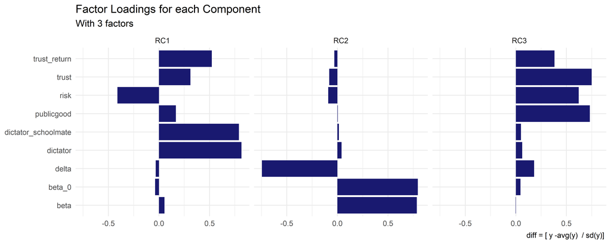

#### 4 Factor PCA

```
##
## Loadings:
##                     RC2    RC1    RC4    RC3
## delta               -0.743                0.218
## beta                 0.784
## beta_0               0.798                0.183
## dictator                    0.172  0.829
## dictator_schoolmate                0.863
## risk                        0.103 -0.109  0.925
## publicgood                  0.840
## trust                       0.716  0.241  0.298
## trust_return                0.609  0.313 -0.184
##
##                  RC2   RC1   RC4   RC3
## SS loadings    1.818 1.652 1.607 1.080
## Proportion Var 0.202 0.184 0.179 0.120
## Cumulative Var 0.202 0.386 0.564 0.684
```

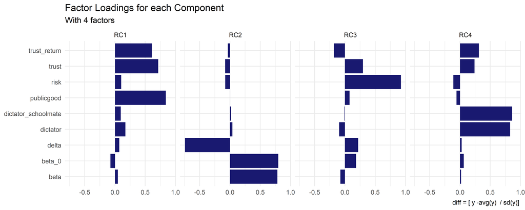

Bottom line: demeaned megmaradtak ugyanazok az eredmények.

A továbbiakban a 4 faktoros PCA-val számoltam. Az elemek elnevezései a következők:

- RC1.: interakciót igénylő társas preferenciák
- RC2: időpreferencia
- RC4: Interakciót nem igénylő társas preferenciák
- RC3: kockázati preferencia

## Random Forest

Az ÖSSZES további Random Forest illesztésben a “math” változóra illesztettem a fákat. Lehet még olyat is illeszteni, ahol pl. top 15% percentilisre lövünk.

Random forest math változóra; PCA változók nélkül

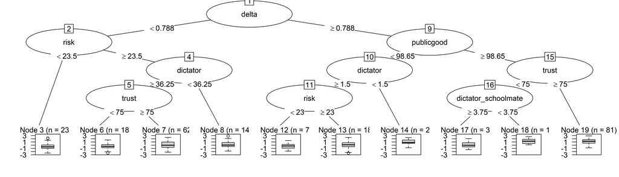

Összehasonlítás a nyers változókkal:

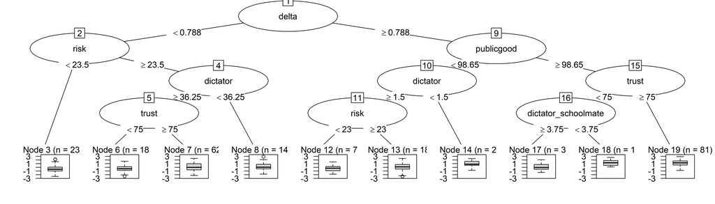

## Sima lineáris regresszió - PCA-kkal

```
##
## Call:
## lm(formula = math ~ pca_socpref_interact + pca_timepref + pca_socpref_nointeract +
##     pca_riskpref + comp + age + read, data = data_analysis_clean)
##
## Residuals:
##      Min       1Q   Median       3Q      Max
## -2.12484 -0.45134 -0.03091  0.41369  1.70478
##
## Coefficients:
##                         Estimate Std. Error t value Pr(>|t|)
## (Intercept)             1.078434   0.302030   3.571 0.000373 ***
## pca_socpref_interact   -0.105981   0.020294  -5.222 2.14e-07 ***
## pca_timepref            0.082879   0.020435   4.056 5.38e-05 ***
## pca_socpref_nointeract  0.091916   0.020882   4.402 1.19e-05 ***
## pca_riskpref           -0.092291   0.020361  -4.533 6.51e-06 ***
## comp                   -0.035552   0.041205  -0.863 0.388437
## age                    -0.005251   0.001492  -3.521 0.000449 ***
## read                    0.679662   0.021324  31.872  < 2e-16 ***
## ---
## Signif. codes:  0 '***' 0.001 '**' 0.01 '*' 0.05 '.' 0.1 ' ' 1
##
## Residual standard error: 0.6388 on 1027 degrees of freedom
## Multiple R-squared:  0.5944, Adjusted R-squared:  0.5916
## F-statistic:   215 on 7 and 1027 DF,  p-value: < 2.2e-16
```

A két regresszió közti R-négyzet különbség is nagyon durva.

```
##
## Call:
## lm(formula = math ~ pca_socpref_interact + pca_timepref + pca_socpref_nointeract +
##     pca_riskpref + comp, data = data_analysis_clean)
##
## Residuals:
##      Min       1Q   Median       3Q      Max
## -2.51091 -0.62879 -0.04265  0.62997  2.71137
##
## Coefficients:
##                        Estimate Std. Error t value Pr(>|t|)
## (Intercept)             0.08411    0.04612   1.824   0.0685 .
## pca_socpref_interact   -0.19007    0.02887  -6.584 7.29e-11 ***
## pca_timepref            0.18390    0.02895   6.352 3.18e-10 ***
## pca_socpref_nointeract  0.26569    0.02881   9.221  < 2e-16 ***
## pca_riskpref           -0.14948    0.02906  -5.143 3.23e-07 ***
## comp                   -0.14242    0.05889  -2.419   0.0158 *
## ---
## Signif. codes:  0 '***' 0.001 '**' 0.01 '*' 0.05 '.' 0.1 ' ' 1
##
## Residual standard error: 0.9165 on 1029 degrees of freedom
## Multiple R-squared:  0.1634, Adjusted R-squared:  0.1594
## F-statistic:  40.2 on 5 and 1029 DF,  p-value: < 2.2e-16
```

diff adatokra illesztve:

```
##
## Call:
## lm(formula = math ~ delta + beta + dictator + dictator_schoolmate +
##     risk + publicgood + trust + trust_return + age + read, data = data_analysis_clean)
##
## Residuals:
##      Min       1Q   Median       3Q      Max
## -2.00866 -0.44492 -0.04313  0.40543  1.70331
##
## Coefficients:
##                       Estimate Std. Error t value Pr(>|t|)
## (Intercept)          0.3056056  0.3515066   0.869 0.384823
## delta                0.8887876  0.1431228   6.210 7.69e-10 ***
## beta                 0.0396752  0.0967348   0.410 0.681786
## dictator            -0.0061925  0.0013051  -4.745 2.38e-06 ***
## dictator_schoolmate -0.0004417  0.0011412  -0.387 0.698813
## risk                 0.0012728  0.0011486   1.108 0.268064
## publicgood           0.0020142  0.0008042   2.505 0.012416 *
## trust                0.0030597  0.0009493   3.223 0.001308 **
## trust_return        -0.0010855  0.0013467  -0.806 0.420403
## age                 -0.0051905  0.0014750  -3.519 0.000452 ***
## read                 0.6737490  0.0210903  31.946  < 2e-16 ***
## ---
## Signif. codes:  0 '***' 0.001 '**' 0.01 '*' 0.05 '.' 0.1 ' ' 1
##
## Residual standard error: 0.6307 on 1024 degrees of freedom
## Multiple R-squared:  0.6057, Adjusted R-squared:  0.6019
## F-statistic: 157.3 on 10 and 1024 DF,  p-value: < 2.2e-16
```

## Klasszifikáció a legjobb 20% matekosra

Ha a legjobb 20% matekosra futtatok klasszifikációt, akkor a legfontosabbak a klasszifikáció szempontjából a következők:

- trust
- delta
- trust_return
- fontos még a dictator_schoolmate (de csak 33 eset klasszifikációjában ebben a futtatásban)

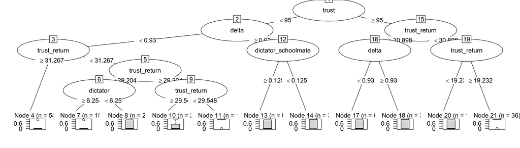

Random Forest PCA-kkal:

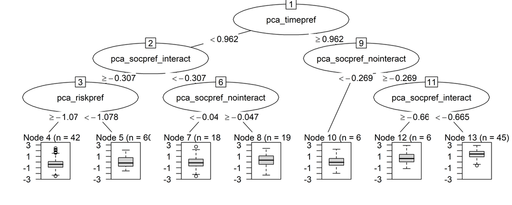

Mivel jóval kevesebb változó van, kevésbé tudja szétszedni a jókat.

Összességében: - A “Node 9”-ben vannak a jobb teljesítményű diákok (n=130) : social_preferencbe nagyon alacsony a score-juk, time preferencbe pedig magasabb.

# Random forest - read

“read változóra megcsinálom az előző elemezést:

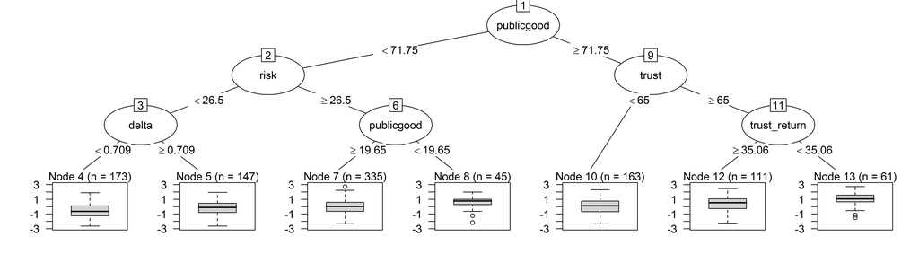

Összehasonlítás a nyers változókkal:

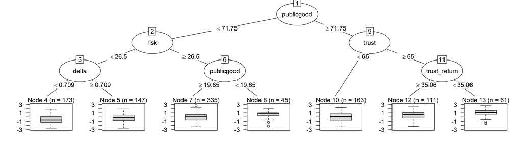

### Sima lineáris regresszió - PCA-kkal

Nagyon érdekes: a matekkal ellentétben itt a socpref_nointeract ami dominál (dictator game)

```
##
## Call:
## lm(formula = read ~ pca_socpref_interact + pca_timepref + pca_socpref_nointeract +
##     pca_riskpref + comp + age + math, data = data_analysis_clean)
##
## Residuals:
##      Min       1Q   Median       3Q      Max
## -2.23238 -0.44788  0.02751  0.43505  2.15973
##
## Coefficients:
##                         Estimate Std. Error t value Pr(>|t|)
## (Intercept)             0.377744   0.315086   1.199  0.23086
## pca_socpref_interact    0.015143   0.021329   0.710  0.47788
## pca_timepref            0.015453   0.021366   0.723  0.46969
## pca_socpref_nointeract  0.066348   0.021771   3.048  0.00237 **
## pca_riskpref            0.021067   0.021326   0.988  0.32344
## comp                   -0.037143   0.042751  -0.869  0.38515
## age                    -0.001731   0.001556  -1.113  0.26608
## math                    0.731643   0.022955  31.872  < 2e-16 ***
## ---
## Signif. codes:  0 '***' 0.001 '**' 0.01 '*' 0.05 '.' 0.1 ' ' 1
##
## Residual standard error: 0.6627 on 1027 degrees of freedom
## Multiple R-squared:  0.5654, Adjusted R-squared:  0.5624
## F-statistic: 190.9 on 7 and 1027 DF,  p-value: < 2.2e-16
```

diff adatokra illesztve:

```
##
## Call:
## lm(formula = read ~ delta + beta + dictator + dictator_schoolmate +
##     risk + publicgood + trust + trust_return + age, data = data_analysis_clean)
##
## Residuals:
##      Min       1Q   Median       3Q      Max
## -2.64344 -0.65503  0.03691  0.65707  2.55191
##
## Coefficients:
##                      Estimate Std. Error t value Pr(>|t|)
## (Intercept)          1.081746   0.519484   2.082 0.037558 *
## delta                0.877683   0.210185   4.176 3.22e-05 ***
## beta                -0.012612   0.143264  -0.088 0.929865
## dictator            -0.002144   0.001932  -1.110 0.267212
## dictator_schoolmate -0.002846   0.001688  -1.686 0.092070 .
## risk                 0.009713   0.001674   5.803 8.68e-09 ***
## publicgood           0.003117   0.001187   2.625 0.008782 **
## trust                0.005437   0.001396   3.895 0.000104 ***
## trust_return        -0.003783   0.001991  -1.900 0.057675 .
## age                 -0.011009   0.002157  -5.103 3.98e-07 ***
## ---
## Signif. codes:  0 '***' 0.001 '**' 0.01 '*' 0.05 '.' 0.1 ' ' 1
##
## Residual standard error: 0.9341 on 1025 degrees of freedom
## Multiple R-squared:  0.1384, Adjusted R-squared:  0.1308
## F-statistic: 18.29 on 9 and 1025 DF,  p-value: < 2.2e-16
```

```
##
## Call:
## lm(formula = read ~ delta + beta + dictator + dictator_schoolmate +
##     risk + publicgood + trust + trust_return + age, data = data)
##
## Residuals:
##      Min       1Q   Median       3Q      Max
## -2.64344 -0.65503  0.03691  0.65707  2.55191
##
## Coefficients:
##                      Estimate Std. Error t value Pr(>|t|)
## (Intercept)          1.081746   0.519484   2.082 0.037558 *
## delta                0.877683   0.210185   4.176 3.22e-05 ***
## beta                -0.012612   0.143264  -0.088 0.929865
## dictator            -0.002144   0.001932  -1.110 0.267212
## dictator_schoolmate -0.002846   0.001688  -1.686 0.092070 .
## risk                 0.009713   0.001674   5.803 8.68e-09 ***
## publicgood           0.003117   0.001187   2.625 0.008782 **
## trust                0.005437   0.001396   3.895 0.000104 ***
## trust_return        -0.003783   0.001991  -1.900 0.057675 .
## age                 -0.011009   0.002157  -5.103 3.98e-07 ***
## ---
## Signif. codes:  0 '***' 0.001 '**' 0.01 '*' 0.05 '.' 0.1 ' ' 1
##
## Residual standard error: 0.9341 on 1025 degrees of freedom
##   (73 observations deleted due to missingness)
## Multiple R-squared:  0.1384, Adjusted R-squared:  0.1308
## F-statistic: 18.29 on 9 and 1025 DF,  p-value: < 2.2e-16
```

# Clustering - demeanelt adatokra

(Mindegyik esetben 5 klaszternél húztam meg a határt. )

Complete clustering:

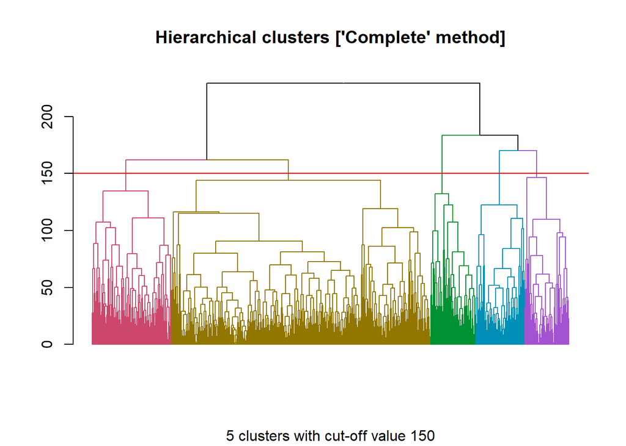

[figure not shown]

K-means clustering:

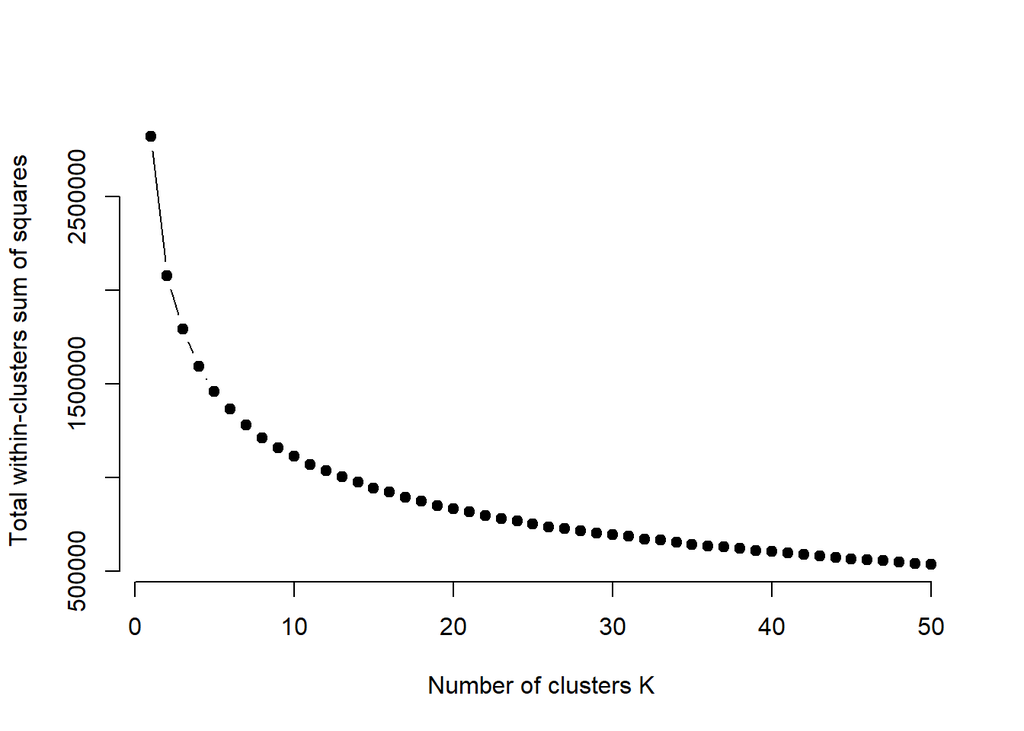

Now knowing that the number of factors is the same, I run the K-means clustering algorithm for 5 clusters:

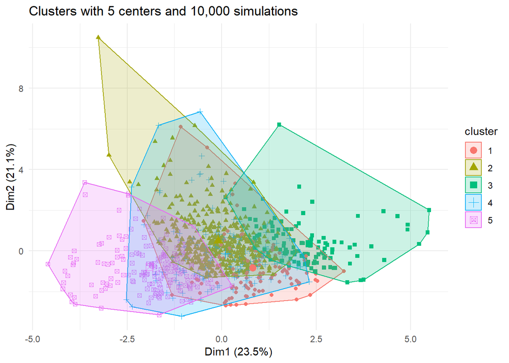

MCLUST clustering : (model based clustering)

(for more on that: https://cran.r-project.org/web/packages/mclust/vignettes/mclust.html)

```
## Package 'mclust' version 5.4.9
```

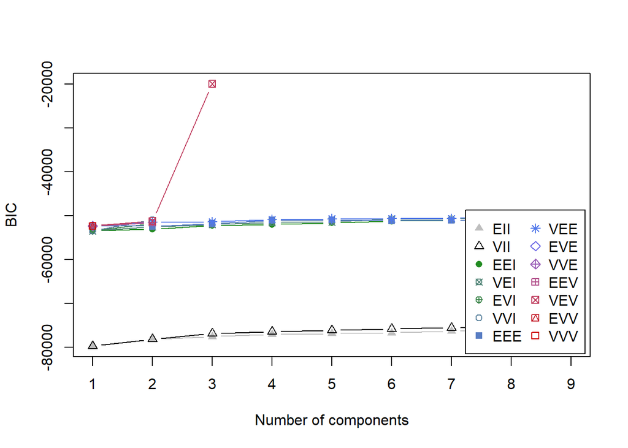

```
## ----------------------------------------------------
## Gaussian finite mixture model fitted by EM algorithm
## ----------------------------------------------------
##
## Mclust VEV (ellipsoidal, equal shape) model with 3 components:
##
##  log-likelihood    n  df       BIC       ICL
##       -9453.606 1035 148 -19934.65 -20154.81
##
## Clustering table:
##   1   2   3
## 502 437  96
##
## Mixing probabilities:
##          1          2          3
## 0.45206339 0.44963745 0.09829916
##
## Means:
##                           [,1]       [,2]       [,3]
## delta                0.7345756  0.7877313  0.6061717
## beta                 1.1020513  0.8815153  1.3836009
## beta_0               0.1020513  0.1184847  0.3836009
## dictator            44.2245006 36.7133604 27.0024701
## dictator_schoolmate 28.9117799 27.0385530 22.3215297
## risk                31.7165668 36.3367029 30.2349279
## publicgood          59.6933081 61.5627409 59.7074545
## trust               56.0000686 56.0953174 47.7004774
## trust_return        38.3260300 38.3147009 40.3547245
##
## Variances:
## [,,1]
##                            delta         beta       beta_0     dictator
## delta                0.024621501 -0.008983587 -0.008983587   0.12705430
## beta                -0.008983587  0.014120096  0.014120097   0.06072836
## beta_0              -0.008983587  0.014120097  0.014120098   0.06072828
## dictator             0.127054303  0.060728355  0.060728281 202.67740484
## dictator_schoolmate -0.094704588  0.200607146  0.200607114 119.36052518
## risk                 0.203656350 -0.149039064 -0.149039073 -34.04785430
## publicgood           0.410345235 -0.160367419 -0.160367469  61.22725543
## trust                0.542399509 -0.267177507 -0.267177581  99.42082099
```

[output cut: 68 more lines]

[output not shown]

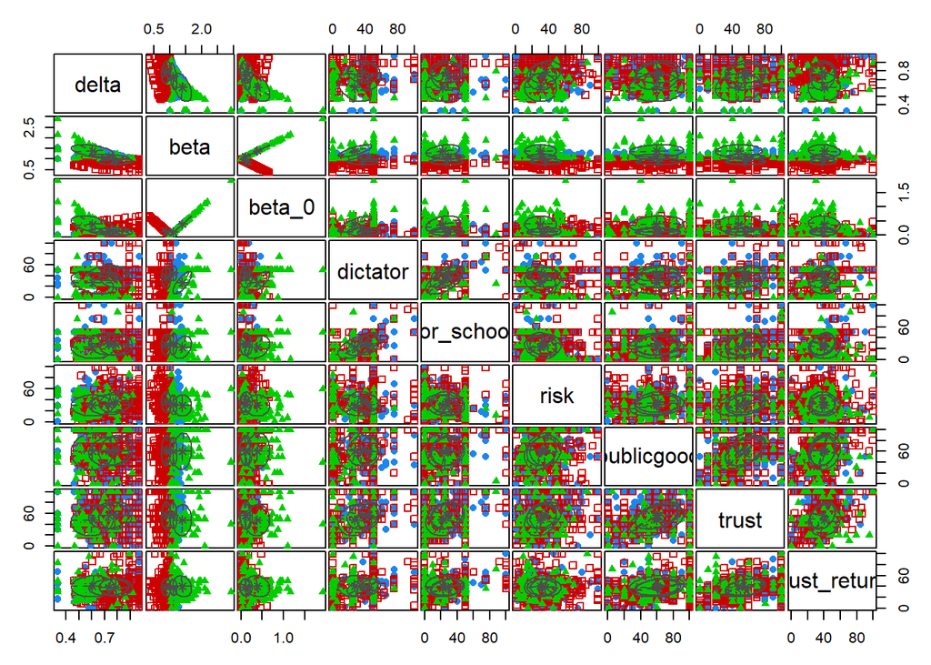

#### Cross-table of various observations using the two clustering algorithms:

##### Complete Hierarchical vs K-means:

Hierarchical clusters (row) vs. k-means cluster (columns)

|  | 1 | 2 | 3 | 4 | 5 |
| --- | --- | --- | --- | --- | --- |
| 1 | 12 | 338 | 3 | 160 | 49 |
| 2 | 3 | 32 | 0 | 11 | 126 |
| 3 | 86 | 1 | 7 | 3 | 1 |
| 4 | 4 | 67 | 29 | 3 | 4 |
| 5 | 11 | 3 | 78 | 4 | 0 |

##### Complete Hierarchical vs McQuitty Hierarchical:

| 1 | 2 | 3 | 4 | 5 |
| --- | --- | --- | --- | --- |
| 505 | 1 | 20 | 0 | 36 |
| 170 | 0 | 2 | 0 | 0 |
| 31 | 65 | 2 | 0 | 0 |
| 91 | 0 | 16 | 0 | 0 |
| 25 | 37 | 24 | 10 | 0 |

##### McQuitty Hierarchical vs K-means:

Hierarchical clusters [McQuitty] (row) vs. k-means cluster (columns)

|  | 1 | 2 | 3 | 4 | 5 |
| --- | --- | --- | --- | --- | --- |
| 1 | 48 | 431 | 40 | 123 | 180 |
| 2 | 68 | 0 | 35 | 0 | 0 |
| 3 | 0 | 10 | 32 | 22 | 0 |
| 4 | 0 | 0 | 10 | 0 | 0 |
| 5 | 0 | 0 | 0 | 36 | 0 |

Összehasonlítás summary:

(k-mean cluster szempontjából) az 1-es és 2-es klaszterek nagyon hasonló, a többiben szórnak a klaszterezési metódusok.

# Clusters 1 and 2

```
##
##
## |                            |    1 (N=116)     |    2 (N=441)     |    3 (N=117)     |    4 (N=181)     |    5 (N=180)    | Total (N=1035)  | p value|
## |:---------------------------|:----------------:|:----------------:|:----------------:|:----------------:|:---------------:|:---------------:|-------:|
## |**delta**                   |                  |                  |                  |                  |                 |                 | < 0.001|
## |&nbsp;&nbsp;&nbsp;Mean (SD) |  0.795 (0.157)   |  0.716 (0.145)   |  0.783 (0.150)   |  0.759 (0.155)   |  0.749 (0.154)  |  0.746 (0.153)  |        |
## |&nbsp;&nbsp;&nbsp;Range     |  0.333 - 0.971   |  0.333 - 0.971   |  0.333 - 0.971   |  0.333 - 0.971   |  0.333 - 0.971  |  0.333 - 0.971  |        |
## |**beta**                    |                  |                  |                  |                  |                 |                 |   0.267|
## |&nbsp;&nbsp;&nbsp;Mean (SD) |  1.019 (0.231)   |  1.043 (0.235)   |  1.002 (0.173)   |  1.041 (0.239)   |  1.014 (0.188)  |  1.031 (0.222)  |        |
## |&nbsp;&nbsp;&nbsp;Range     |  0.343 - 2.158   |  0.343 - 2.913   |  0.417 - 1.890   |  0.343 - 2.087   |  0.534 - 1.858  |  0.343 - 2.913  |        |
## |**dictator**                |                  |                  |                  |                  |                 |                 | < 0.001|
## |&nbsp;&nbsp;&nbsp;Mean (SD) | 31.898 (20.258)  |  46.454 (9.505)  | 54.354 (14.760)  | 36.644 (17.085)  | 18.589 (15.619) | 39.154 (18.196) |        |
## |&nbsp;&nbsp;&nbsp;Range     |  0.000 - 75.000  | 5.000 - 100.000  | 0.000 - 100.000  |  0.000 - 60.000  | 0.000 - 50.000  | 0.000 - 100.000 |        |
## |**dictator_schoolmate**     |                  |                  |                  |                  |                 |                 | < 0.001|
## |&nbsp;&nbsp;&nbsp;Mean (SD) | 10.446 (13.285)  | 33.823 (15.318)  | 53.094 (15.847)  | 23.870 (17.750)  | 9.563 (11.780)  | 27.422 (20.215) |        |
## |&nbsp;&nbsp;&nbsp;Range     |  0.000 - 50.000  | 0.000 - 100.000  | 25.000 - 100.000 |  0.000 - 50.000  | 0.000 - 50.000  | 0.000 - 100.000 |        |
## |**risk**                    |                  |                  |                  |                  |                 |                 | < 0.001|
## |&nbsp;&nbsp;&nbsp;Mean (SD) | 48.353 (19.120)  | 27.383 (14.761)  | 38.034 (20.437)  | 34.724 (18.460)  | 35.589 (18.241) | 33.648 (18.471) |        |
## |&nbsp;&nbsp;&nbsp;Range     |  1.000 - 99.000  |  1.000 - 75.000  |  1.000 - 99.000  |  1.000 - 99.000  | 1.000 - 90.000  | 1.000 - 99.000  |        |
## |**publicgood**              |                  |                  |                  |                  |                 |                 | < 0.001|
## |&nbsp;&nbsp;&nbsp;Mean (SD) | 84.498 (20.304)  | 47.114 (13.739)  | 86.964 (17.597)  | 89.346 (12.111)  | 31.826 (19.685) | 60.535 (27.615) |        |
## |&nbsp;&nbsp;&nbsp;Range     | 20.000 - 100.000 |  0.000 - 75.000  | 40.000 - 100.000 | 65.000 - 100.000 | 0.000 - 70.000  | 0.000 - 100.000 |        |
## |**trust**                   |                  |                  |                  |                  |                 |                 | < 0.001|
## |&nbsp;&nbsp;&nbsp;Mean (SD) | 92.414 (11.914)  | 50.181 (14.739)  | 89.829 (12.593)  | 44.862 (14.048)  | 31.556 (17.523) | 55.227 (25.127) |        |
## |&nbsp;&nbsp;&nbsp;Range     | 50.000 - 100.000 | 10.000 - 100.000 | 60.000 - 100.000 |  0.000 - 70.000  | 0.000 - 80.000  | 0.000 - 100.000 |        |
## |**trust_return**            |                  |                  |                  |                  |                 |                 | < 0.001|
## |&nbsp;&nbsp;&nbsp;Mean (SD) | 39.440 (18.941)  | 39.577 (11.838)  | 49.509 (17.864)  | 38.340 (14.217)  | 28.377 (16.881) | 38.520 (15.874) |        |
## |&nbsp;&nbsp;&nbsp;Range     | 0.000 - 100.000  |  8.258 - 84.563  | 5.000 - 100.000  |  0.000 - 86.085  | 0.000 - 95.450  | 0.000 - 100.000 |        |
## |**comp**                    |                  |                  |                  |                  |                 |                 |   0.496|
## |&nbsp;&nbsp;&nbsp;Mean (SD) |  0.681 (0.468)   |  0.603 (0.490)   |  0.590 (0.494)   |  0.641 (0.481)   |  0.600 (0.491)  |  0.616 (0.486)  |        |
## |&nbsp;&nbsp;&nbsp;Range     |  0.000 - 1.000   |  0.000 - 1.000   |  0.000 - 1.000   |  0.000 - 1.000   |  0.000 - 1.000  |  0.000 - 1.000  |        |
## |**pca_socpref_interact**    |                  |                  |                  |                  |                 |                 |   0.014|
```

[output cut: 17 more lines]

```
##
## Call:
## lm(formula = kmeans_cluster ~ as.factor(schoolid), data = data_analysis_clean)
##
## Residuals:
##     Min      1Q  Median      3Q     Max
## -2.1263 -0.9394 -0.5934  1.0944  2.4066
##
## Coefficients:
##                      Estimate Std. Error t value Pr(>|t|)
## (Intercept)           2.93939    0.16132  18.221   <2e-16 ***
## as.factor(schoolid)2 -0.03381    0.18274  -0.185    0.853
## as.factor(schoolid)3  0.02239    0.19226   0.116    0.907
## as.factor(schoolid)4 -0.22753    0.23480  -0.969    0.333
## as.factor(schoolid)5 -0.31313    0.20826  -1.504    0.133
## as.factor(schoolid)6 -0.13520    0.19502  -0.693    0.488
## as.factor(schoolid)7 -0.34599    0.21189  -1.633    0.103
## as.factor(schoolid)8  0.18692    0.21000   0.890    0.374
## as.factor(schoolid)9  0.13669    0.21140   0.647    0.518
## ---
## Signif. codes:  0 '***' 0.001 '**' 0.01 '*' 0.05 '.' 0.1 ' ' 1
##
## Residual standard error: 1.311 on 1026 degrees of freedom
## Multiple R-squared:  0.0151, Adjusted R-squared:  0.00742
## F-statistic: 1.966 on 8 and 1026 DF,  p-value: 0.04758
```